# HW3-ECG200

Hakan Ekiz - IE48B - Fall2021

12 Aralık 2021

## Homework Information

### Distance Measurements

1- Euclidian 2- DTW (Windows size=10) 3- DTW (Window size=20) 4- ERP

### K nn classifiers

1- k=1 2- k=3 3- k=5

### Datasets

1- ECG200 2- Plane 3- SyntheticControl 4- Trace 5- SmoothSubspace

Note: Since it takes time to run 5 different datasets in the same file and convert them to reports, 5 different files will be loaded for 5 different datasets.

## Libraries and Functions

```r
require(data.table)
require(ggplot2)
require(repr)
require(rpart)
require(rattle)
require(TSrepr)
require(TSdist)
require(dtw)
require(zoo)
require(genlasso)
require(e1071)
```

```r
options(repr.plot.width=15, repr.plot.height=8)
```

```r
nn_classify_cv=function(dist_matrix,train_class,test_indices,k=1){

    test_distances_to_train=dist_matrix[test_indices,]
    test_distances_to_train=test_distances_to_train[,-test_indices]
    train_class=train_class[-test_indices]
    #print(str(test_distances_to_train))
    ordered_indices=apply(test_distances_to_train,1,order)
    if(k==1){
        nearest_class=as.numeric(trainclass[as.numeric(ordered_indices[1,])])
        nearest_class=data.table(id=test_indices,nearest_class)
    } else {
        nearest_class=apply(ordered_indices[1:k,],2,function(x) {trainclass[x]})
        nearest_class=data.table(id=test_indices,t(nearest_class))
    }

    long_nn_class=melt(nearest_class,'id')

    class_counts=long_nn_class[,.N,list(id,value)]
    class_counts[,predicted_prob:=N/k]
    wide_class_prob_predictions=dcast(class_counts,id~value,value.var='predicted_prob')
    wide_class_prob_predictions[is.na(wide_class_prob_predictions)]=0
    class_predictions=class_counts[,list(predicted=value[which.max(N)]),by=list(id)]


    return(list(prediction=class_predictions,prob_estimates=wide_class_prob_predictions))

}
```

# ECG200

TrainSize=100 TestSize=100 Length=96 Number of Class=2

## Data

```r
current_folder=getwd()
dataset='ECG200'
main_path=sprintf('%s/ClassificationData/%s/%s',current_folder,dataset,dataset)

dist_path=sprintf('%s/ClassificationData/%s/distances/%s',current_folder,dataset,dataset)

train_data_path=sprintf('%s_TRAIN.txt',main_path)
traindata=as.matrix(fread(train_data_path))

test_data_path=sprintf('%s_TEST.txt',main_path)
testdata=as.matrix(fread(test_data_path))

#first column is the class variable
trainclass=traindata[,1] # takes -1 and 1
testclass=testdata[,1] # takes -1 and 1

#drop first column
traindata=traindata[,2:ncol(traindata)]
testdata=testdata[,2:ncol(testdata)]

# instance characteristics
tlength=ncol(traindata)
n_series_train=nrow(traindata)
n_series_test=nrow(testdata)
```

```r
head(data.table(traindata))
```

```
##           V2        V3        V4        V5         V6         V7          V8
## 1: 0.5020555 0.5421626 0.7223835 1.4288852 2.13651580  2.2811490  1.93627370
## 2: 0.1476469 0.8046684 0.3677715 0.2438937 0.02661388 -0.2744021  0.09673058
## 3: 0.3166462 0.2431991 0.3704714 1.0637381 1.67818710  1.7595575  1.69771720
## 4: 1.1688741 2.0759008 1.7601405 1.6064459 1.94904560  1.3028421  0.45933154
## 5: 0.6486575 0.7520260 2.6362312 3.4557156 2.11815740  0.5206202 -0.18862656
## 6: 0.4047327 1.2808587 2.5151479 1.2995187 1.45343230  0.4742751 -1.39656190
##            V9        V10        V11         V12        V13        V14
## 1:  1.4688900  1.0088451  0.3802822 -0.29677967 -0.5139287 -0.2556447
## 2: -0.7477306 -1.6097771 -1.1795931 -1.05592640 -1.1287774 -0.6860387
## 3:  1.6121590  1.1681877  0.4999570 -0.02236253 -0.2353182 -0.1182725
## 4:  0.5164121  0.8521795  0.9892272  0.82125349  0.5764476  0.7430894
## 5:  0.7808184  0.9337747  0.7014020  1.00613300  0.3957838 -0.3697030
## 6: -0.6470808  0.4319451  0.1324451 -0.40660902  0.2305663 -0.1213527
##            V15        V16        V17         V18        V19        V20
```

[output cut: 90 more lines]

```r
dt_ts_train=data.table(traindata)
dt_ts_train[,id:=1:.N]
long_train=melt(dt_ts_train,id.vars=c('id'))
long_train[,time:=as.numeric(gsub("\\D", "", variable))-1]
long_train=long_train[order(id,time)]
long_train[,diff_series:=value-shift(value,1),by=list(id)]
head(long_train)
```

```
##    id variable     value time diff_series
## 1:  1       V2 0.5020555    1          NA
## 2:  1       V3 0.5421626    2  0.04010717
## 3:  1       V4 0.7223835    3  0.18022083
## 4:  1       V5 1.4288852    4  0.70650172
## 5:  1       V6 2.1365158    5  0.70763060
## 6:  1       V7 2.2811490    6  0.14463320
```

```r
head(dt_ts_train)
```

```
##           V2        V3        V4        V5         V6         V7          V8
## 1: 0.5020555 0.5421626 0.7223835 1.4288852 2.13651580  2.2811490  1.93627370
## 2: 0.1476469 0.8046684 0.3677715 0.2438937 0.02661388 -0.2744021  0.09673058
## 3: 0.3166462 0.2431991 0.3704714 1.0637381 1.67818710  1.7595575  1.69771720
## 4: 1.1688741 2.0759008 1.7601405 1.6064459 1.94904560  1.3028421  0.45933154
## 5: 0.6486575 0.7520260 2.6362312 3.4557156 2.11815740  0.5206202 -0.18862656
## 6: 0.4047327 1.2808587 2.5151479 1.2995187 1.45343230  0.4742751 -1.39656190
##            V9        V10        V11         V12        V13        V14
## 1:  1.4688900  1.0088451  0.3802822 -0.29677967 -0.5139287 -0.2556447
## 2: -0.7477306 -1.6097771 -1.1795931 -1.05592640 -1.1287774 -0.6860387
## 3:  1.6121590  1.1681877  0.4999570 -0.02236253 -0.2353182 -0.1182725
## 4:  0.5164121  0.8521795  0.9892272  0.82125349  0.5764476  0.7430894
## 5:  0.7808184  0.9337747  0.7014020  1.00613300  0.3957838 -0.3697030
## 6: -0.6470808  0.4319451  0.1324451 -0.40660902  0.2305663 -0.1213527
##            V15        V16        V17         V18        V19        V20
```

[output cut: 90 more lines]

```r
dt_ts_test=data.table(testdata)
dt_ts_test[,id:=1:.N]
long_test=melt(dt_ts_test,id.vars=c('id'))
long_test[,time:=as.numeric(gsub("\\D", "", variable))-1]
long_test=long_test[order(id,time)]
long_test[,diff_series:=value-shift(value,1),by=list(id)]
head(long_test)
```

```
##    id variable     value time diff_series
## 1:  1       V2 0.4251894    1          NA
## 2:  1       V3 1.4185988    2   0.9934094
## 3:  1       V4 2.6687913    3   1.2501925
## 4:  1       V5 3.2986290    4   0.6298377
## 5:  1       V6 2.2645539    5  -1.0340751
## 6:  1       V7 0.1651795    6  -2.0993744
```

```r
head(dt_ts_test)
```

```
##           V2       V3        V4       V5        V6         V7         V8
## 1: 0.4251894 1.418599 2.6687913 3.298629 2.2645539  0.1651795 -0.9597265
## 2: 0.6539293 2.177290 3.6447828 2.279203 0.9783674 -0.3882958 -0.9119111
## 3: 0.4049532 0.553996 0.7240971 1.449039 2.0126163  1.6244769  1.2047262
## 4: 1.0880883 2.011949 2.3017332 1.630199 0.6367680 -0.1405017  0.5479535
## 5: 0.4436209 0.947285 1.9240844 2.159790 1.4994468  0.9645078  0.2232562
## 6: 0.2094264 1.273329 2.8243142 3.592306 2.2236616  0.5703741 -0.9387727
##            V9         V10         V11        V12        V13         V14
## 1:  0.2826684  0.84285041  0.68345828  1.0820879  0.7225769  0.10981136
## 2: -0.1483295  0.30543881 -0.23009793 -0.4515303  0.2241126 -0.55005370
## 3:  1.1175109  0.56209949 -0.01155647 -0.1510597 -0.1657235 -0.14970342
## 4:  1.0750706  0.89686111  1.13794280  1.0467255  0.3901595 -0.46317712
## 5: -0.4249456  0.12127867  0.83019719  0.7270480  0.6488297  0.78787726
## 6: -0.8128027 -0.00935859 -0.26645765 -0.2793572 -0.2596680 -0.04298028
##           V15        V16        V17        V18        V19        V20        V21
```

[output cut: 90 more lines]

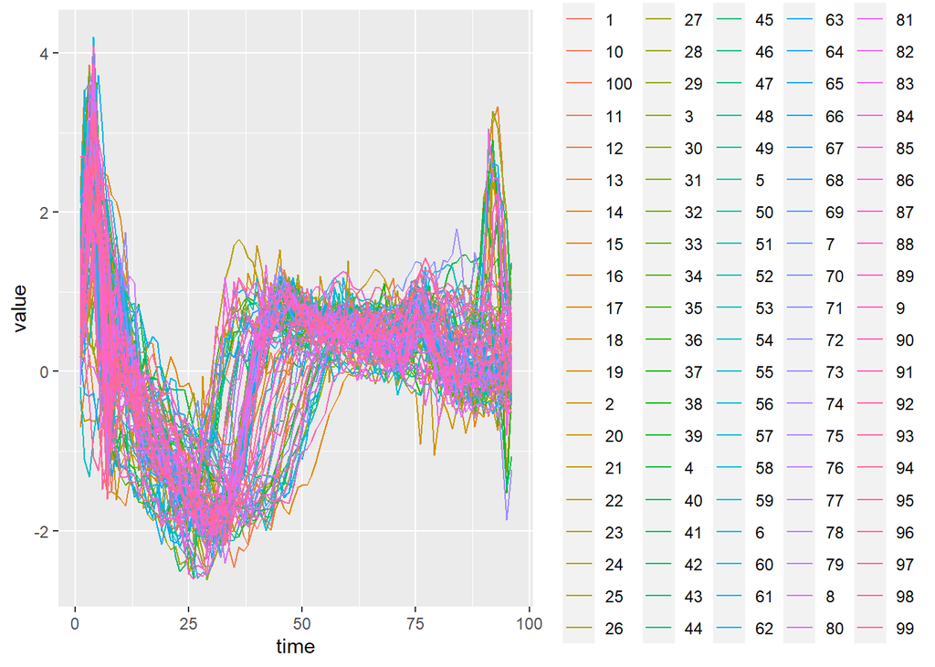

```r
ggplot(long_train, aes(time,value)) + geom_line(aes(color=as.character(id)))
```

## Representations

PAA with segmenth length = 5 PLA with n_important = 10 Tree with maxdepth = 12

```r
#Piecewise Aggregate + Piecewise Linear Approximation + Tree


segmentlength = 5
n_important = 10

long_train=long_train[order(id,time)]

treeres <- vector('list', n_series_train)
paares <- vector('list', n_series_train)

for (i in 1:n_series_train) {

  data_plot=long_train[id==i]

  data_ts=long_train[id==i]$value
  paa_rep=repr_paa(data_ts, segmentlength , meanC)
  dummy_time = c(1:(length(paa_rep)-1))*segmentlength
  dummy_time = c(dummy_time, (nrow(data_plot)))
  dt_paa = data.table(time=dummy_time, paa_rep)

  pla_rep=repr_pla(data_ts, times = n_important, return = "points")
  pla_rep=repr_pla(data_ts, times = n_important, return = "both")
  setnames(pla_rep,c('places','points'),c('time','pla_rep'))
  pla_rep$time=pla_rep$time+1


  tree=rpart(value~time,data_plot,control=rpart.control(cp=0,maxdepth=12,minsplit=20,minbucket=10))
  data_plot[,tree_rep:=predict(tree,data_plot)]


  data_plot=merge(data_plot,dt_paa,by='time',all.x=T)
  data_plot=merge(data_plot,pla_rep,by='time',all.x=T)

  data_plot[,paa_rep:=nafill(paa_rep,'nocb')]
  data_plot[, pla_rep := na.approx(pla_rep)]

  paares[[i]]=data_plot

}
results <- rbindlist(paares)
```

```r
head(results)
```

```
##    time id variable     value diff_series tree_rep  paa_rep   pla_rep
## 1:    1  1       V2 0.5020555          NA 1.240744 1.066401 0.5020555
## 2:    2  1       V3 0.5421626  0.04010717 1.240744 1.066401 0.5654042
## 3:    3  1       V4 0.7223835  0.18022083 1.240744 1.066401 0.6287529
## 4:    4  1       V5 1.4288852  0.70650172 1.240744 1.066401 0.6921016
## 5:    5  1       V6 2.1365158  0.70763060 1.240744 1.066401 0.7554503
## 6:    6  1       V7 2.2811490  0.14463320 1.240744 1.415088 0.8187990
```

Sample representaion for id=10

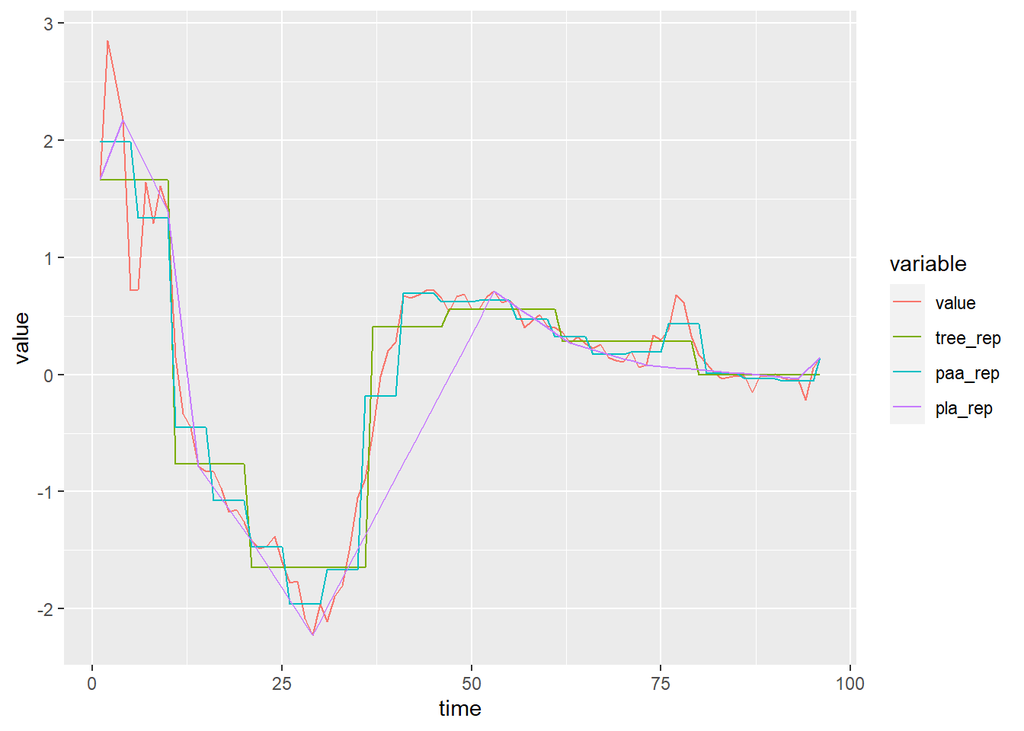

```r
selected=results[id==10]
data_show=melt(selected,id.vars='time',measure.vars=c('value','tree_rep', 'paa_rep', 'pla_rep'))
ggplot(data_show,aes(x=time,y=value,color=variable))+
    geom_line()
```

## Distance Measurement

Preliminary work with results dataset for future distance calculations;

Euc Dtw (window size = 10) Dtw (window size = 20) ERP

```r
value_train=dcast(results[!is.na(value)],id~time,value.var='value')
head(value_train)
```

```
##    id         1         2         3         4          5          6           7
## 1:  1 0.5020555 0.5421626 0.7223835 1.4288852 2.13651580  2.2811490  1.93627370
## 2:  2 0.1476469 0.8046684 0.3677715 0.2438937 0.02661388 -0.2744021  0.09673058
## 3:  3 0.3166462 0.2431991 0.3704714 1.0637381 1.67818710  1.7595575  1.69771720
## 4:  4 1.1688741 2.0759008 1.7601405 1.6064459 1.94904560  1.3028421  0.45933154
## 5:  5 0.6486575 0.7520260 2.6362312 3.4557156 2.11815740  0.5206202 -0.18862656
## 6:  6 0.4047327 1.2808587 2.5151479 1.2995187 1.45343230  0.4742751 -1.39656190
##             8          9         10          11         12         13
## 1:  1.4688900  1.0088451  0.3802822 -0.29677967 -0.5139287 -0.2556447
## 2: -0.7477306 -1.6097771 -1.1795931 -1.05592640 -1.1287774 -0.6860387
## 3:  1.6121590  1.1681877  0.4999570 -0.02236253 -0.2353182 -0.1182725
## 4:  0.5164121  0.8521795  0.9892272  0.82125349  0.5764476  0.7430894
## 5:  0.7808184  0.9337747  0.7014020  1.00613300  0.3957838 -0.3697030
## 6: -0.6470808  0.4319451  0.1324451 -0.40660902  0.2305663 -0.1213527
##             14         15         16          17         18         19
```

[output cut: 90 more lines]

```r
value_train=as.matrix(value_train)
```

```r
diff_train=dcast(results[!is.na(diff_series)],id~time,value.var='diff_series')
head(diff_train)
```

```
##    id           2          3          4          5          6          7
## 1:  1  0.04010717  0.1802208  0.7065017  0.7076306  0.1446332 -0.3448753
## 2:  2  0.65702150 -0.4368969 -0.1238778 -0.2172798 -0.3010160  0.3711327
## 3:  3 -0.07344708  0.1272724  0.6932667  0.6144490  0.0813704 -0.0618403
## 4:  4  0.90702670 -0.3157603 -0.1536946  0.3425997 -0.6462035 -0.8435106
## 5:  5  0.10336843  1.8842052  0.8194844 -1.3375582 -1.5975372 -0.7092468
## 6:  6  0.87612605  1.2342892 -1.2156292  0.1539136 -0.9791572 -1.8708370
##              8          9         10         11         12         13
## 1: -0.46738370 -0.4600449 -0.6285629 -0.6770619 -0.2171490  0.2582840
## 2: -0.84446122 -0.8620465  0.4301840  0.1236667 -0.0728510  0.4427387
## 3: -0.08555820 -0.4439713 -0.6682307 -0.5223196 -0.2129556  0.1170457
## 4:  0.05708058  0.3357674  0.1370476 -0.1679737 -0.2448058  0.1666418
## 5:  0.96944497  0.1529563 -0.2323727  0.3047310 -0.6103492 -0.7654868
## 6:  0.74948111  1.0790259 -0.2995000 -0.5390541  0.6371754 -0.3519190
##             14          15         16         17          18          19
```

[output cut: 97 more lines]

```r
diff_train=as.matrix(diff_train)
```

```r
tree_train=dcast(results[!is.na(tree_rep)],id~time,value.var='tree_rep')
head(tree_train)
```

```
##    id          1          2          3          4          5          6
## 1:  1  1.2407443  1.2407443  1.2407443  1.2407443  1.2407443  1.2407443
## 2:  2 -0.2124178 -0.2124178 -0.2124178 -0.2124178 -0.2124178 -0.2124178
## 3:  3  0.7116314  0.7116314  0.7116314  0.7116314  0.7116314  0.7116314
## 4:  4  1.1195829  1.1195829  1.1195829  1.1195829  1.1195829  1.1195829
## 5:  5  1.1467244  1.1467244  1.1467244  1.1467244  1.1467244  1.1467244
## 6:  6  0.4347167  0.4347167  0.4347167  0.4347167  0.4347167  0.4347167
##             7          8          9         10         11         12         13
## 1:  1.2407443  1.2407443  1.2407443  1.2407443 -0.4041319 -0.4041319 -0.4041319
## 2: -0.2124178 -0.2124178 -0.2124178 -0.2124178 -1.2297844 -1.2297844 -1.2297844
## 3:  0.7116314  0.7116314  0.7116314  0.7116314  0.7116314  0.7116314  0.7116314
## 4:  1.1195829  1.1195829  1.1195829  1.1195829  1.1195829  1.1195829  1.1195829
## 5:  1.1467244  1.1467244  1.1467244  1.1467244  1.1467244  1.1467244 -0.9414546
## 6:  0.4347167  0.4347167  0.4347167  0.4347167  0.4347167  0.4347167  0.4347167
##            14         15         16         17         18         19         20
```

[output cut: 83 more lines]

```r
tree_train=as.matrix(tree_train)
```

```r
paa_train=dcast(results[!is.na(paa_rep)],id~time,value.var='paa_rep')
head(paa_train)
```

```
##    id         1         2         3         4         5          6          7
## 1:  1 1.0664005 1.0664005 1.0664005 1.0664005 1.0664005  1.4150880  1.4150880
## 2:  2 0.3181189 0.3181189 0.3181189 0.3181189 0.3181189 -0.7429545 -0.7429545
## 3:  3 0.7344484 0.7344484 0.7344484 0.7344484 0.7344484  1.3475157  1.3475157
## 4:  4 1.7120814 1.7120814 1.7120814 1.7120814 1.7120814  0.8239985  0.8239985
## 5:  5 1.9221575 1.9221575 1.9221575 1.9221575 1.9221575  0.5495978  0.5495978
## 6:  6 1.3907380 1.3907380 1.3907380 1.3907380 1.3907380 -0.2009955 -0.2009955
##             8          9         10          11          12          13
## 1:  1.4150880  1.4150880  1.4150880 -0.29227643 -0.29227643 -0.29227643
## 2: -0.7429545 -0.7429545 -0.7429545 -1.07676205 -1.07676205 -1.07676205
## 3:  1.3475157  1.3475157  1.3475157 -0.15399340 -0.15399340 -0.15399340
## 4:  0.8239985  0.8239985  0.8239985  0.66024382  0.66024382  0.66024382
## 5:  0.5495978  0.5495978  0.5495978 -0.08701449 -0.08701449 -0.08701449
## 6: -0.2009955 -0.2009955 -0.2009955 -0.49256121 -0.49256121 -0.49256121
##             14          15         16         17         18         19
```

[output cut: 90 more lines]

```r
paa_train=as.matrix(paa_train)
```

```r
pla_train=dcast(results[!is.na(pla_rep)],id~time,value.var='pla_rep')
head(pla_train)
```

```
##    id         1          2          3          4          5          6
## 1:  1 0.5020555  0.5654042  0.6287529  0.6921016  0.7554503  0.8187990
## 2:  2 0.1476469 -0.0720311 -0.2917091 -0.5113871 -0.7310651 -0.9507431
## 3:  3 0.3166462  0.5017194  0.6867927  0.8718659  1.0569392  1.2420125
## 4:  4 1.1688741  1.0506170  0.9323599  0.8141028  0.6958457  0.5775886
## 5:  5 0.6486575  1.5843435  2.5200296  3.4557156  2.2409349  1.0261542
## 6:  6 0.4047327  0.1045169 -0.1956989 -0.4959146 -0.7961304 -1.0963461
##             7          8          9         10          11         12
## 1:  0.8821477  0.9454964  1.0088451  0.8050088  0.60117250  0.3973362
## 2: -1.1704211 -1.3900991 -1.6097771 -1.6270427 -1.64430834 -1.6615740
## 3:  1.4270857  1.6121590  1.4555196  1.2988801  1.14224066  0.9856012
## 4:  0.4593315  0.6359634  0.8125953  0.9892272  0.80262420  0.6160212
## 5: -0.1886266  0.1100633  0.4087532  0.7074431  1.00613300  0.7306216
## 6: -1.3965619 -0.4823084  0.4319451  0.1776139 -0.07671739 -0.3310486
##            13          14          15         16         17          18
```

[output cut: 97 more lines]

```r
pla_train=as.matrix(pla_train)
```

```r
large_number=10000
```

### Euclidian

Raw, difference, tree, paa(piecewise aggregate approximation with segmenth length 5) and pla values are used.

```r
# raw + euc
dist_euc=as.matrix(dist(value_train))
diag(dist_euc)=large_number
fwrite(dist_euc,sprintf('%s_euc_raw_dist.csv',dist_path),col.names=F)
```

```
## x being coerced from class: matrix to data.table
```

```r
# diif + euc
dist_diff=as.matrix(dist(diff_train))
diag(dist_diff)=large_number
fwrite(dist_diff,sprintf('%s_euc_diff_dist.csv',dist_path),col.names=F)
```

```
## x being coerced from class: matrix to data.table
```

```r
# tree + euc
dist_tree=as.matrix(dist(tree_train))
diag(dist_tree)=large_number
fwrite(dist_tree,sprintf('%s_euc_tree_dist.csv',dist_path),col.names=F)
```

```
## x being coerced from class: matrix to data.table
```

```r
# paa + euc
dist_paa=as.matrix(dist(paa_train))
diag(dist_paa)=large_number
fwrite(dist_paa,sprintf('%s_euc_paa_dist.csv',dist_path),col.names=F)
```

```
## x being coerced from class: matrix to data.table
```

```r
# pla + euc
dist_pla=as.matrix(dist(pla_train))
diag(dist_pla)=large_number
fwrite(dist_pla,sprintf('%s_euc_pla_dist.csv',dist_path),col.names=F)
```

```
## x being coerced from class: matrix to data.table
```

```r
# raw + DTW(Window size = 10)
dist_dtw=as.matrix(dtwDist(value_train, window.type='sakoechiba',window.size=10))
diag(dist_dtw)=large_number
fwrite(dist_dtw,sprintf('%s_dtw_raw_dist_10ws.csv',dist_path),col.names=F)
```

```
## x being coerced from class: matrix to data.table
```

```r
# diff + DTW(Window size = 10)
dist_dtw_diff=as.matrix(dtwDist(diff_train, window.type='sakoechiba',window.size=10))
diag(dist_dtw_diff)=large_number
fwrite(dist_dtw_diff,sprintf('%s_dtw_diff_dist_10ws.csv',dist_path),col.names=F)
```

```
## x being coerced from class: matrix to data.table
```

```r
# tree + DTW(window size = 10)
dist_dtw_tree=as.matrix(dtwDist(tree_train, window.type='sakoechiba',window.size=10))
diag(dist_dtw_tree)=large_number
fwrite(dist_dtw_tree,sprintf('%s_dtw_tree_dist_10ws.csv',dist_path),col.names=F)
```

```
## x being coerced from class: matrix to data.table
```

```r
# paa + DTW(window size = 10)
dist_dtw_paa=as.matrix(dtwDist(paa_train, window.type='sakoechiba',window.size=10))
diag(dist_dtw_paa)=large_number
fwrite(dist_dtw_paa,sprintf('%s_dtw_paa_dist_10ws.csv',dist_path),col.names=F)
```

```
## x being coerced from class: matrix to data.table
```

```r
# pla + DTW(window size = 10)
dist_dtw_pla=as.matrix(dtwDist(pla_train, window.type='sakoechiba',window.size=10))
diag(dist_dtw_pla)=large_number
fwrite(dist_dtw_pla,sprintf('%s_dtw_pla_dist_10ws.csv',dist_path),col.names=F)
```

```
## x being coerced from class: matrix to data.table
```

```r
# raw + DTW(Window size = 20)
dist_dtw2=as.matrix(dtwDist(value_train, window.type='sakoechiba',window.size=20))
diag(dist_dtw2)=large_number
fwrite(dist_dtw2,sprintf('%s_dtw_raw_dist_20ws.csv',dist_path),col.names=F)
```

```
## x being coerced from class: matrix to data.table
```

```r
# diff + DTW(Window size = 20)
dist_dtw_diff2=as.matrix(dtwDist(diff_train, window.type='sakoechiba',window.size=20))
diag(dist_dtw_diff2)=large_number
fwrite(dist_dtw_diff2,sprintf('%s_dtw_diff_dist_20ws.csv',dist_path),col.names=F)
```

```
## x being coerced from class: matrix to data.table
```

```r
# tree + DTW(window size = 20)
dist_dtw_tree2=as.matrix(dtwDist(tree_train, window.type='sakoechiba',window.size=20))
diag(dist_dtw_tree2)=large_number
fwrite(dist_dtw_tree2,sprintf('%s_dtw_tree_dist_20ws.csv',dist_path),col.names=F)
```

```
## x being coerced from class: matrix to data.table
```

```r
# paa + DTW(window size = 20)
dist_dtw_paa2=as.matrix(dtwDist(paa_train, window.type='sakoechiba',window.size=20))
diag(dist_dtw_paa2)=large_number
fwrite(dist_dtw_paa2,sprintf('%s_dtw_paa_dist_20ws.csv',dist_path),col.names=F)
```

```
## x being coerced from class: matrix to data.table
```

```r
# pla + DTW(window size = 20)
dist_dtw_pla2=as.matrix(dtwDist(pla_train, window.type='sakoechiba',window.size=20))
diag(dist_dtw_pla2)=large_number
fwrite(dist_dtw_pla2,sprintf('%s_dtw_pla_dist_20ws.csv',dist_path),col.names=F)
```

```
## x being coerced from class: matrix to data.table
```

```r
# raw + ERP(g=1)
dist_erp=TSDatabaseDistances(value_train,distance='erp',g=1)
dist_erp=as.matrix(dist_erp)
diag(dist_erp)=large_number
fwrite(dist_erp,sprintf('%s_erp_raw_gap_1.csv',dist_path),col.names=F)
```

```
## x being coerced from class: matrix to data.table
```

```r
# diff + ERP(g=1)
dist_erp_diff=TSDatabaseDistances(diff_train,distance='erp',g=1)
dist_erp_diff=as.matrix(dist_erp_diff)
diag(dist_erp_diff)=large_number
fwrite(dist_erp_diff,sprintf('%s_erp_diff_gap_1.csv',dist_path),col.names=F)
```

```
## x being coerced from class: matrix to data.table
```

```r
# tree + ERP(g=1)
dist_erp_tree=TSDatabaseDistances(tree_train,distance='erp',g=1)
dist_erp_tree=as.matrix(dist_erp_tree)
diag(dist_erp_tree)=large_number
fwrite(dist_erp_tree,sprintf('%s_erp_tree_gap_1.csv',dist_path),col.names=F)
```

```
## x being coerced from class: matrix to data.table
```

```r
# paa + ERP(g=1)
dist_erp_paa=TSDatabaseDistances(paa_train,distance='erp',g=1)
dist_erp_paa=as.matrix(dist_erp_paa)
diag(dist_erp_paa)=large_number
fwrite(dist_erp_paa,sprintf('%s_erp_paa_gap_1.csv',dist_path),col.names=F)
```

```
## x being coerced from class: matrix to data.table
```

```r
# pla + ERP(g=1)
dist_erp_pla=TSDatabaseDistances(pla_train,distance='erp',g=1)
dist_erp_pla=as.matrix(dist_erp_pla)
diag(dist_erp_pla)=large_number
fwrite(dist_erp_pla,sprintf('%s_erp_pla_gap_1.csv',dist_path),col.names=F)
```

```
## x being coerced from class: matrix to data.table
```

## Comparisons

```r
# cv indices start here
require(TunePareto)
set.seed(13429)
nof_rep=5
n_fold=10
cv_indices=generateCVRuns(trainclass, ntimes =nof_rep, nfold = n_fold,
                          leaveOneOut = FALSE, stratified = TRUE)

str(cv_indices)
```

```
## List of 5
##  $ Run  1:List of 10
##   ..$ Fold  1 : int [1:10] 54 58 89 19 82 64 55 42 41 10
##   ..$ Fold  2 : int [1:10] 91 84 85 70 53 67 74 71 52 46
##   ..$ Fold  3 : int [1:10] 86 28 94 56 22 59 25 77 80 43
##   ..$ Fold  4 : int [1:10] 8 47 45 12 76 40 81 39 16 5
##   ..$ Fold  5 : int [1:10] 97 4 98 33 17 38 90 65 75 29
##   ..$ Fold  6 : int [1:10] 48 73 50 34 11 61 6 100 79 21
##   ..$ Fold  7 : int [1:10] 57 20 1 30 83 32 88 63 14 78
##   ..$ Fold  8 : int [1:10] 87 15 7 13 26 68 23 27 72 35
##   ..$ Fold  9 : int [1:10] 66 44 3 93 31 60 95 92 9 51
##   ..$ Fold  10: int [1:10] 36 62 24 49 37 96 18 2 99 69
##  $ Run  2:List of 10
##   ..$ Fold  1 : int [1:10] 28 50 7 48 31 61 18 59 41 25
##   ..$ Fold  2 : int [1:10] 84 3 62 93 11 64 32 10 52 79
##   ..$ Fold  3 : int [1:10] 86 20 89 55 83 63 40 27 99 70
##   ..$ Fold  4 : int [1:10] 15 57 1 17 72 60 29 34 95 80
##   ..$ Fold  5 : int [1:10] 66 24 8 33 51 81 35 49 5 82
##   ..$ Fold  6 : int [1:10] 44 73 94 22 56 6 16 13 71 77
##   ..$ Fold  7 : int [1:10] 36 47 45 42 90 75 68 38 69 26
##   ..$ Fold  8 : int [1:10] 54 58 19 21 74 43 37 67 88 9
##   ..$ Fold  9 : int [1:10] 4 91 85 96 23 53 30 65 100 92
##   ..$ Fold  10: int [1:10] 98 97 87 39 46 14 12 76 78 2
##  $ Run  3:List of 10
##   ..$ Fold  1 : int [1:10] 57 36 66 89 13 53 43 49 35 52
##   ..$ Fold  2 : int [1:10] 97 73 4 11 79 72 29 42 76 77
##   ..$ Fold  3 : int [1:10] 28 84 54 30 99 39 32 6 67 34
##   ..$ Fold  4 : int [1:10] 98 8 62 65 46 27 23 22 2 75
##   ..$ Fold  5 : int [1:10] 48 45 20 10 59 17 96 9 63 18
##   ..$ Fold  6 : int [1:10] 87 85 44 68 40 90 95 88 83 37
##   ..$ Fold  7 : int [1:10] 3 7 58 41 74 71 61 78 60 14
##   ..$ Fold  8 : int [1:10] 15 94 50 82 55 80 5 38 64 12
##   ..$ Fold  9 : int [1:10] 47 86 19 25 56 70 26 33 31 51
##   ..$ Fold  10: int [1:10] 91 24 1 92 69 81 16 93 100 21
##  $ Run  4:List of 10
##   ..$ Fold  1 : int [1:10] 57 44 4 73 32 71 42 69 59 29
##   ..$ Fold  2 : int [1:10] 85 24 7 90 74 55 30 23 64 82
##   ..$ Fold  3 : int [1:10] 58 8 1 10 93 46 40 81 83 99
##   ..$ Fold  4 : int [1:10] 54 3 89 75 61 52 21 76 16 80
##   ..$ Fold  5 : int [1:10] 98 66 86 6 77 18 14 92 95 35
##   ..$ Fold  6 : int [1:10] 94 15 50 5 11 63 9 78 38 70
##   ..$ Fold  7 : int [1:10] 48 87 91 56 37 60 68 72 96 67
##   ..$ Fold  8 : int [1:10] 62 97 36 53 13 17 27 79 22 43
##   ..$ Fold  9 : int [1:10] 45 20 84 65 33 41 51 31 25 12
##   ..$ Fold  10: int [1:10] 19 28 47 100 26 2 34 88 49 39
##  $ Run  5:List of 10
##   ..$ Fold  1 : int [1:10] 24 45 73 20 75 51 90 95 60 74
##   ..$ Fold  2 : int [1:10] 1 4 50 10 31 72 30 35 32 93
##   ..$ Fold  3 : int [1:10] 85 15 87 11 17 83 92 78 49 22
##   ..$ Fold  4 : int [1:10] 7 58 57 61 88 96 71 16 82 79
##   ..$ Fold  5 : int [1:10] 98 47 97 25 80 9 59 99 5 42
##   ..$ Fold  6 : int [1:10] 86 19 94 29 6 63 14 53 65 12
##   ..$ Fold  7 : int [1:10] 89 91 36 81 27 2 68 70 69 37
##   ..$ Fold  8 : int [1:10] 66 62 48 23 43 77 18 52 13 46
##   ..$ Fold  9 : int [1:10] 44 54 84 64 39 41 34 67 21 26
##   ..$ Fold  10: int [1:10] 3 8 28 76 38 55 56 100 40 33
```

```r
dist_folder=sprintf('%s/ClassificationData/%s/distances/',current_folder,dataset)
dist_files=list.files(dist_folder, full.names=T)
```

```r
list.files(dist_folder)
```

```
##  [1] "ECG200_dtw_diff_dist_10ws.csv" "ECG200_dtw_diff_dist_20ws.csv"
##  [3] "ECG200_dtw_paa_dist_10ws.csv"  "ECG200_dtw_paa_dist_20ws.csv"
##  [5] "ECG200_dtw_pla_dist_10ws.csv"  "ECG200_dtw_pla_dist_20ws.csv"
##  [7] "ECG200_dtw_raw_dist_10ws.csv"  "ECG200_dtw_raw_dist_20ws.csv"
##  [9] "ECG200_dtw_tree_dist_10ws.csv" "ECG200_dtw_tree_dist_20ws.csv"
## [11] "ECG200_erp_diff_gap_1.csv"     "ECG200_erp_paa_gap_1.csv"
## [13] "ECG200_erp_pla_gap_1.csv"      "ECG200_erp_raw_gap_1.csv"
## [15] "ECG200_erp_tree_gap_1.csv"     "ECG200_euc_diff_dist.csv"
## [17] "ECG200_euc_paa_dist.csv"       "ECG200_euc_pla_dist.csv"
## [19] "ECG200_euc_raw_dist.csv"       "ECG200_euc_tree_dist.csv"
```

```r
k_levels=c(1,3,5)
approach_file=list.files(dist_folder)
result=vector('list',length(dist_files)*nof_rep*n_fold*length(k_levels))
iter=1
for(m in 1:length(dist_files)){ #
    print(dist_files[m])
    dist_mat=as.matrix(fread(dist_files[m],header=FALSE))
    for(i in 1:nof_rep){
        this_fold=cv_indices[[i]]
        for(j in 1:n_fold){
            test_indices=this_fold[[j]]
            for(k in 1:length(k_levels)){
                current_k=k_levels[k]
                current_fold=nn_classify_cv(dist_mat,trainclass,test_indices,k=current_k)
                accuracy=sum(trainclass[test_indices]==current_fold$prediction$predicted)/length(test_indices)
                tmp=data.table(approach=approach_file[m],repid=i,foldid=j,
                               k=current_k,acc=accuracy)
                result[[iter]]=tmp
                iter=iter+1

            }

        }

    }

}
```

```
## [1] "C:/Users/Z0047JBE/Desktop/DERSLER SON/IE48B/HW3/ClassificationData/ECG200/distances/ECG200_dtw_diff_dist_10ws.csv"
## [1] "C:/Users/Z0047JBE/Desktop/DERSLER SON/IE48B/HW3/ClassificationData/ECG200/distances/ECG200_dtw_diff_dist_20ws.csv"
## [1] "C:/Users/Z0047JBE/Desktop/DERSLER SON/IE48B/HW3/ClassificationData/ECG200/distances/ECG200_dtw_paa_dist_10ws.csv"
## [1] "C:/Users/Z0047JBE/Desktop/DERSLER SON/IE48B/HW3/ClassificationData/ECG200/distances/ECG200_dtw_paa_dist_20ws.csv"
## [1] "C:/Users/Z0047JBE/Desktop/DERSLER SON/IE48B/HW3/ClassificationData/ECG200/distances/ECG200_dtw_pla_dist_10ws.csv"
## [1] "C:/Users/Z0047JBE/Desktop/DERSLER SON/IE48B/HW3/ClassificationData/ECG200/distances/ECG200_dtw_pla_dist_20ws.csv"
## [1] "C:/Users/Z0047JBE/Desktop/DERSLER SON/IE48B/HW3/ClassificationData/ECG200/distances/ECG200_dtw_raw_dist_10ws.csv"
## [1] "C:/Users/Z0047JBE/Desktop/DERSLER SON/IE48B/HW3/ClassificationData/ECG200/distances/ECG200_dtw_raw_dist_20ws.csv"
## [1] "C:/Users/Z0047JBE/Desktop/DERSLER SON/IE48B/HW3/ClassificationData/ECG200/distances/ECG200_dtw_tree_dist_10ws.csv"
## [1] "C:/Users/Z0047JBE/Desktop/DERSLER SON/IE48B/HW3/ClassificationData/ECG200/distances/ECG200_dtw_tree_dist_20ws.csv"
## [1] "C:/Users/Z0047JBE/Desktop/DERSLER SON/IE48B/HW3/ClassificationData/ECG200/distances/ECG200_erp_diff_gap_1.csv"
## [1] "C:/Users/Z0047JBE/Desktop/DERSLER SON/IE48B/HW3/ClassificationData/ECG200/distances/ECG200_erp_paa_gap_1.csv"
## [1] "C:/Users/Z0047JBE/Desktop/DERSLER SON/IE48B/HW3/ClassificationData/ECG200/distances/ECG200_erp_pla_gap_1.csv"
## [1] "C:/Users/Z0047JBE/Desktop/DERSLER SON/IE48B/HW3/ClassificationData/ECG200/distances/ECG200_erp_raw_gap_1.csv"
## [1] "C:/Users/Z0047JBE/Desktop/DERSLER SON/IE48B/HW3/ClassificationData/ECG200/distances/ECG200_erp_tree_gap_1.csv"
## [1] "C:/Users/Z0047JBE/Desktop/DERSLER SON/IE48B/HW3/ClassificationData/ECG200/distances/ECG200_euc_diff_dist.csv"
## [1] "C:/Users/Z0047JBE/Desktop/DERSLER SON/IE48B/HW3/ClassificationData/ECG200/distances/ECG200_euc_paa_dist.csv"
## [1] "C:/Users/Z0047JBE/Desktop/DERSLER SON/IE48B/HW3/ClassificationData/ECG200/distances/ECG200_euc_pla_dist.csv"
## [1] "C:/Users/Z0047JBE/Desktop/DERSLER SON/IE48B/HW3/ClassificationData/ECG200/distances/ECG200_euc_raw_dist.csv"
## [1] "C:/Users/Z0047JBE/Desktop/DERSLER SON/IE48B/HW3/ClassificationData/ECG200/distances/ECG200_euc_tree_dist.csv"
```

```r
overall_results=rbindlist(result)
summarized_results=overall_results[,list(avg_acc=mean(acc),sdev_acc=sd(acc),result_count=.N),by=list(approach,k)]
summarized_results[order(-avg_acc)]
```

```
##                          approach k avg_acc  sdev_acc result_count
##  1: ECG200_dtw_tree_dist_10ws.csv 5   0.678 0.1130107           50
##  2: ECG200_dtw_tree_dist_20ws.csv 5   0.670 0.1182353           50
##  3:  ECG200_dtw_paa_dist_20ws.csv 5   0.666 0.1222410           50
##  4:       ECG200_euc_raw_dist.csv 5   0.662 0.1353604           50
##  5:  ECG200_dtw_pla_dist_10ws.csv 5   0.660 0.1370238           50
##  6:       ECG200_euc_paa_dist.csv 5   0.658 0.1295046           50
##  7:      ECG200_euc_diff_dist.csv 3   0.656 0.1296148           50
##  8:       ECG200_euc_pla_dist.csv 5   0.656 0.1248019           50
##  9:  ECG200_dtw_paa_dist_10ws.csv 5   0.654 0.1215713           50
## 10:      ECG200_euc_diff_dist.csv 5   0.654 0.1248836           50
## 11:      ECG200_euc_tree_dist.csv 5   0.652 0.1343769           50
## 12: ECG200_dtw_diff_dist_20ws.csv 5   0.650 0.1281740           50
## 13:  ECG200_dtw_raw_dist_20ws.csv 5   0.648 0.1388583           50
## 14: ECG200_dtw_tree_dist_20ws.csv 3   0.646 0.1358420           50
```

[output cut: 47 more lines]

```r
summarized_results[which.max(summarized_results$avg_acc)]
```

```
##                         approach k avg_acc  sdev_acc result_count
## 1: ECG200_dtw_tree_dist_10ws.csv 5   0.678 0.1130107           50
```

Dynamic Time Warping method (window size=10) with classification tree representation and k=5 gives best results between my trials.

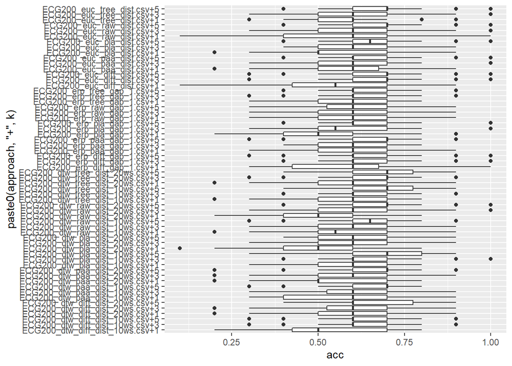

```r
require(ggplot2)
ggplot(overall_results,aes(x=paste0(approach,'+',k), y=acc)) +
geom_boxplot()+
coord_flip()
```